# Simple SIR data simulation

Breck Baldwin

May 18, 2021

# Navigation

This Rmarkdown page exists as part of the [CoDatMo](https://codatmo.github.io/) project. The repo containing this page is at [https://github.com/codatmo/dataGeneratingProcess1](https://github.com/codatmo/dataGeneratingProcess) as ‘index.Rmd’ and rendered as ‘index.html’.

# Model 1

About the simplest SIR model I can think of. Surprisingly error prone process and very sensitive to infection rate. See below. I find it very useful to naively code up a simulation for some problem I am trying to model. I am not an epidemiologist and have no medical training.

I have looked at some infection models so this is not totally naive, see https://mc-stan.org/users/documentation/case-studies/boarding_school_case_study.html which I found to be a good explanation. I have not attempted to reproduce that model here although there is a model reproduction check list I did at https://codatmo.github.io/Simple_SIR/.

I don’t use standard terms like R0, Rt etc because there are subtleties that I am not sure will get right and wanting to keep things naive.

There are likely gross errors which please point out in the issue tracker or send me email.

```r
rm(list = ls()) #clean out the cruft

set.seed(43614)
runModel1 = function(runName = runName,
                     nPop = nPop,
                     nDays = nDays,
                     print = PRINT,
                     probInfectPerContact = probInfectPerContact) {
  dayState = c('i', rep('s', nPop - 1))
  infectionDay = c(1, rep(NA, nPop - 1))

  meanDaysInfectious = 3
  meanContactsPerDay = 10

  #dataM = matrix(nrow = nDays, ncol = 3)
  colNames = c('runName', 'day', 's', 'i', 'r', 'probInfectPerContact')
  df = data.frame(matrix(nrow = 0, ncol=length(colNames)))
  colnames(df) = colNames
  nextDayState = dayState
  for (d in 1:nDays) {
    df[d,] = rep(NA,length(colNames)) #setup data, will cause errors if I miss something
    df[d,]$runName = runName
    df[d,]$s=  length(subset(dayState, dayState == 's'))
    df[d,]$i = length(subset(dayState, dayState == 'i'))
    df[d,]$r = length(subset(dayState, dayState == 'r'))
    df[d,]$day = d
    df[d,]$probInfectPerContact = probInfectPerContact
    #dataM[d,] = c(susceptible, infectious, resolved)
    if (print) {
      cat(
        sprintf(
          "Day=%d, susceptible=%d, infected=%d, resolved=%d\n",
           df[d,]$day, df[d,]$s, df[d,]$i, df[d,]$r))
    }
    for (per in 1:nPop) {
      #end infectious period
      if (dayState[per] == 'i') {
        if (d - infectionDay[per]  > meanDaysInfectious) {
          nextDayState[per] = 'r'
        }
      }
    }
    for (per in 1:nPop) {
      if (dayState[per] == 'i') {
        for (otherPer in sample(1:nPop, meanContactsPerDay)) {
          if (dayState[otherPer] == 's' &&
              rbinom(1, 1, probInfectPerContact) == 1) {
            nextDayState[otherPer] = 'i'
            infectionDay[otherPer] = d
          }
        }
      }
    }
    dayState = nextDayState
  }
  return(df)
}

dataM = runModel1(runName = "1/30", nPop = 1e+04, nDays = 100, print = TRUE, probInfectPerContact = 1/30)
```

```
Day=1, susceptible=9999, infected=1, resolved=0
Day=2, susceptible=9998, infected=2, resolved=0
Day=3, susceptible=9997, infected=3, resolved=0
Day=4, susceptible=9996, infected=4, resolved=0
Day=5, susceptible=9996, infected=4, resolved=0
Day=6, susceptible=9995, infected=3, resolved=2
Day=7, susceptible=9993, infected=4, resolved=3
Day=8, susceptible=9993, infected=3, resolved=4
Day=9, susceptible=9991, infected=5, resolved=4
Day=10, susceptible=9989, infected=6, resolved=5
Day=11, susceptible=9989, infected=4, resolved=7
Day=12, susceptible=9989, infected=4, resolved=7
Day=13, susceptible=9988, infected=3, resolved=9
Day=14, susceptible=9987, infected=2, resolved=11
Day=15, susceptible=9986, infected=3, resolved=11
Day=16, susceptible=9984, infected=5, resolved=11
Day=17, susceptible=9983, infected=5, resolved=12
Day=18, susceptible=9979, infected=8, resolved=13
Day=19, susceptible=9974, infected=12, resolved=14
Day=20, susceptible=9971, infected=13, resolved=16
Day=21, susceptible=9965, infected=18, resolved=17
Day=22, susceptible=9959, infected=20, resolved=21
Day=23, susceptible=9949, infected=25, resolved=26
Day=24, susceptible=9946, infected=25, resolved=29
Day=25, susceptible=9942, infected=23, resolved=35
Day=26, susceptible=9932, infected=27, resolved=41
Day=27, susceptible=9923, infected=26, resolved=51
Day=28, susceptible=9917, infected=29, resolved=54
Day=29, susceptible=9906, infected=36, resolved=58
Day=30, susceptible=9893, infected=39, resolved=68
Day=31, susceptible=9878, infected=45, resolved=77
Day=32, susceptible=9863, infected=54, resolved=83
Day=33, susceptible=9841, infected=65, resolved=94
Day=34, susceptible=9818, infected=75, resolved=107
Day=35, susceptible=9793, infected=85, resolved=122
Day=36, susceptible=9762, infected=101, resolved=137
Day=37, susceptible=9730, infected=111, resolved=159
Day=38, susceptible=9694, infected=124, resolved=182
Day=39, susceptible=9648, infected=145, resolved=207
Day=40, susceptible=9604, infected=158, resolved=238
```

[output cut: 45 more lines]

```
Day=86, susceptible=6100, infected=166, resolved=3734
Day=87, susceptible=6071, infected=151, resolved=3778
Day=88, susceptible=6040, infected=136, resolved=3824
Day=89, susceptible=6008, infected=130, resolved=3862
Day=90, susceptible=5971, infected=129, resolved=3900
Day=91, susceptible=5941, infected=130, resolved=3929
Day=92, susceptible=5923, infected=117, resolved=3960
Day=93, susceptible=5891, infected=117, resolved=3992
Day=94, susceptible=5861, infected=110, resolved=4029
Day=95, susceptible=5834, infected=107, resolved=4059
Day=96, susceptible=5818, infected=105, resolved=4077
Day=97, susceptible=5797, infected=94, resolved=4109
Day=98, susceptible=5775, infected=86, resolved=4139
Day=99, susceptible=5756, infected=78, resolved=4166
Day=100, susceptible=5734, infected=84, resolved=4182
```

Running this showed lots of sensitivity around 1/31 to 1/33 infection rate.

Thought I should graph it, see below, this is for the ‘i’ state or infectious.

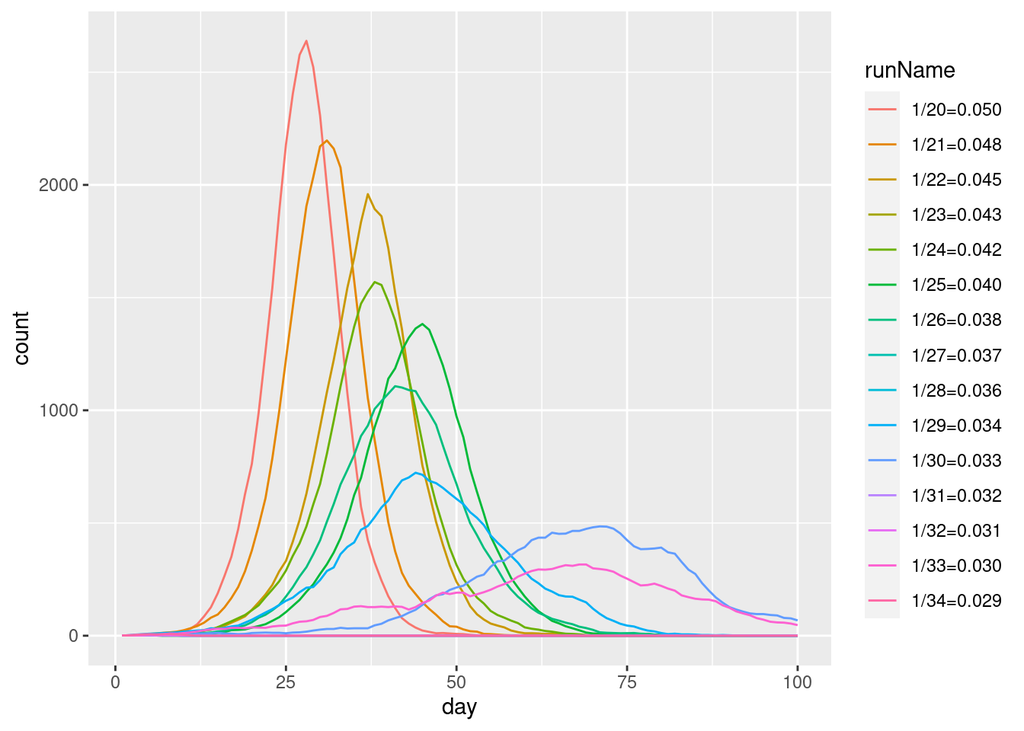

```r
library(tidyverse)
library(ggplot2)

df = data.frame()
for (i in 20:34) {
  df2 = runModel1(runName = sprintf("1/%d=%.3f", i, 1/i), nPop = 1e+04,
                    nDays = 100, print = FALSE, probInfectPerContact = 1/i)
  df = rbind(df,df2)
}

dfLong = gather(df, key = sir, value = count, c(s, i, r))

plot = ggplot(data = dfLong[dfLong$sir == 'i',],
              aes(x = day, y = count, group = runName, color = runName)) +
  geom_line()


print(plot)
```

Above are varying rates of probability of infection per contact for a population of 10,000 for 100 days for the ‘i’ or infected state. Whether patient-zero manages to infect someone is a big issue, real world probably like this too.

```r
nDays = 100
nPop = 1e+04
dataM = runModel1(runName = "1/30", nPop = nPop, nDays = nDays, print = TRUE,
                  probInfectPerContact = 1/30)
```

```
Day=1, susceptible=9999, infected=1, resolved=0
Day=2, susceptible=9999, infected=1, resolved=0
Day=3, susceptible=9999, infected=1, resolved=0
Day=4, susceptible=9998, infected=2, resolved=0
Day=5, susceptible=9998, infected=2, resolved=0
Day=6, susceptible=9995, infected=4, resolved=1
Day=7, susceptible=9992, infected=7, resolved=1
Day=8, susceptible=9990, infected=8, resolved=2
Day=9, susceptible=9990, infected=8, resolved=2
Day=10, susceptible=9988, infected=7, resolved=5
Day=11, susceptible=9983, infected=9, resolved=8
Day=12, susceptible=9978, infected=12, resolved=10
Day=13, susceptible=9972, infected=18, resolved=10
Day=14, susceptible=9965, infected=23, resolved=12
Day=15, susceptible=9952, infected=31, resolved=17
Day=16, susceptible=9947, infected=31, resolved=22
Day=17, susceptible=9934, infected=38, resolved=28
Day=18, susceptible=9926, infected=39, resolved=35
Day=19, susceptible=9913, infected=39, resolved=48
Day=20, susceptible=9903, infected=44, resolved=53
Day=21, susceptible=9888, infected=46, resolved=66
Day=22, susceptible=9872, infected=54, resolved=74
Day=23, susceptible=9852, infected=61, resolved=87
Day=24, susceptible=9836, infected=67, resolved=97
Day=25, susceptible=9816, infected=72, resolved=112
Day=26, susceptible=9785, infected=87, resolved=128
Day=27, susceptible=9749, infected=103, resolved=148
Day=28, susceptible=9717, infected=119, resolved=164
Day=29, susceptible=9677, infected=139, resolved=184
Day=30, susceptible=9628, infected=157, resolved=215
Day=31, susceptible=9574, infected=175, resolved=251
Day=32, susceptible=9526, infected=191, resolved=283
Day=33, susceptible=9476, infected=201, resolved=323
Day=34, susceptible=9419, infected=209, resolved=372
Day=35, susceptible=9349, infected=225, resolved=426
Day=36, susceptible=9291, infected=235, resolved=474
Day=37, susceptible=9230, infected=246, resolved=524
Day=38, susceptible=9154, infected=265, resolved=581
Day=39, susceptible=9071, infected=278, resolved=651
Day=40, susceptible=8992, infected=299, resolved=709
```

[output cut: 45 more lines]

```
Day=86, susceptible=5437, infected=36, resolved=4527
Day=87, susceptible=5430, infected=33, resolved=4537
Day=88, susceptible=5424, infected=27, resolved=4549
Day=89, susceptible=5422, infected=23, resolved=4555
Day=90, susceptible=5419, infected=18, resolved=4563
Day=91, susceptible=5411, infected=19, resolved=4570
Day=92, susceptible=5409, infected=15, resolved=4576
Day=93, susceptible=5406, infected=16, resolved=4578
Day=94, susceptible=5405, infected=14, resolved=4581
Day=95, susceptible=5401, infected=10, resolved=4589
Day=96, susceptible=5400, infected=9, resolved=4591
Day=97, susceptible=5399, infected=7, resolved=4594
Day=98, susceptible=5397, infected=8, resolved=4595
Day=99, susceptible=5396, infected=5, resolved=4599
Day=100, susceptible=5396, infected=4, resolved=4600
```

```r
library("cmdstanr")

# Run from command line: Rscript run.R
# If running from RStudio remember to set the working directory
# >Session>Set Working Directory>To Source File Location

model <- cmdstan_model("stan/sir_negbin.stan")

stan_data <- list(n_days = nrow(dataM), y0 = c(nPop -1, 1, 0), t0 = 0,
                  ts = 1:nDays, N = nPop, cases = dataM$i, compute_likelihood = 1)

fit <- model$sample(data=stan_data, output_dir="output", num_cores = 4,
                    num_chains = 4)
```

```
Running MCMC with 4 parallel chains...

Chain 2 Iteration:    1 / 2000 [  0%]  (Warmup)
```

[output not shown]

[output cut: 13 more lines]

```
Chain 4 Iteration: 1200 / 2000 [ 60%]  (Sampling)
Chain 3 Iteration: 1700 / 2000 [ 85%]  (Sampling)
Chain 4 Iteration: 1300 / 2000 [ 65%]  (Sampling)
Chain 3 Iteration: 1800 / 2000 [ 90%]  (Sampling)
Chain 4 Iteration: 1400 / 2000 [ 70%]  (Sampling)
Chain 3 Iteration: 1900 / 2000 [ 95%]  (Sampling)
Chain 4 Iteration: 1500 / 2000 [ 75%]  (Sampling)
Chain 3 Iteration: 2000 / 2000 [100%]  (Sampling)
Chain 3 finished in 20.4 seconds.
Chain 4 Iteration: 1600 / 2000 [ 80%]  (Sampling)
Chain 4 Iteration: 1700 / 2000 [ 85%]  (Sampling)
Chain 4 Iteration: 1800 / 2000 [ 90%]  (Sampling)
Chain 4 Iteration: 1900 / 2000 [ 95%]  (Sampling)
Chain 4 Iteration: 2000 / 2000 [100%]  (Sampling)
Chain 4 finished in 24.6 seconds.
```

[output not shown]

```r
print(fit$summary(variables = c('pred_cases')))
```

```
# A tibble: 100 x 10
   variable        mean median    sd   mad    q5   q95  rhat ess_bulk ess_tail
   <chr>          <dbl>  <dbl> <dbl> <dbl> <dbl> <dbl> <dbl>    <dbl>    <dbl>
 1 pred_cases[1]   1.20      1  1.13  1.48     0     3  1.00    2909.    2859.
 2 pred_cases[2]   1.38      1  1.24  1.48     0     4  1.00    2902.    2821.
 3 pred_cases[3]   1.63      1  1.37  1.48     0     4  1.00    2904.    2834.
 4 pred_cases[4]   1.92      2  1.49  1.48     0     5  1.00    2501.    2775.
 5 pred_cases[5]   2.30      2  1.63  1.48     0     5  1.00    2910.    2814.
 6 pred_cases[6]   2.67      2  1.77  1.48     0     6  1.00    3104.    3025.
 7 pred_cases[7]   3.15      3  1.97  1.48     0     7  1.00    2959.    2507.
 8 pred_cases[8]   3.75      3  2.22  1.48     1     8  1.00    2983.    2753.
 9 pred_cases[9]   4.36      4  2.42  2.97     1     9  1.00    3055.    2929.
10 pred_cases[10]  5.13      5  2.66  2.97     1    10  1.00    3049.    2995.
# … with 90 more rows
```

# Adding tweets

Below is a very simple data generating process that produces tweets in addition to modeling a SIR compartment model.

```r
rm(list = ls())
set.seed(43614)
runSim2 = function(runName = runName,
                     nPop = nPop,
                     nDays = nDays,
                     print = PRINT,
                     probInfectPerContact = probInfectPerContact,
                     probTweet = probTweet,
                   probDeath = probDeath) {
  dayState = c('i', rep('s', nPop - 1))
  infectionDay = c(1, rep(NA, nPop - 1))
  tweets = rep(0, nPop)
  deaths = rep(0,nPop)

  meanDaysInfectious = 3
  meanContactsPerDay = 10

  #dataM = matrix(nrow = nDays, ncol = 3)
  colNames = c('runName', 'day', 's', 'i', 'r', 'probInfectPerContact', 'tweets','deaths')
  df = data.frame(matrix(nrow = 0, ncol=length(colNames)))
  colnames(df) = colNames
  nextDayState = dayState
  for (d in 1:nDays) {
    df[d,] = rep(NA,length(colNames)) #setup data, will cause errors if I miss something
    df[d,]$runName = runName
    df[d,]$s=  length(subset(dayState, dayState == 's'))
    df[d,]$i = length(subset(dayState, dayState == 'i'))
    df[d,]$r = length(subset(dayState, dayState == 'r'))
    df[d,]$day = d
    df[d,]$probInfectPerContact = probInfectPerContact
    df[d,]$tweets = sum(tweets)
    df[d,]$deaths = sum(deaths)

    #dataM[d,] = c(susceptible, infectious, resolved)
    if (print) {
      cat(
        sprintf(
          "Day=%d, susceptible=%d, infected=%d, resolved=%d, tweets=%d, deaths=%d\n",
          df[d,]$day, df[d,]$s, df[d,]$i, df[d,]$r, df[d,]$tweets, df[d,]$deaths))
    }
    tweets = rep(0, nPop) #start fresh every day, certainly wrong.
    for (per in 1:nPop) {
      #end infectious period
      if (dayState[per] == 'i') {
        if (d - infectionDay[per]  > meanDaysInfectious) {
          nextDayState[per] = 'r'
          if (rbinom(1,1,probDeath) == 1) { #do they die?
            deaths[per] = 1;
          }
        }
      }
    }
    for (per in 1:nPop) {
      if (dayState[per] == 'i') {
        tweets[per] = rbinom(1, 1, probTweet)
        for (otherPer in sample(1:nPop, meanContactsPerDay)) {
          if (dayState[otherPer] == 's' &&
              rbinom(1, 1, probInfectPerContact) == 1) {
            nextDayState[otherPer] = 'i'
            infectionDay[otherPer] = d
          }
        }
      }
    }
    dayState = nextDayState
  }
  return(df)
}
nWeeks = 10
nDays = nWeeks * 7
nPop = 1e+04
deathsTweetsDf = runSim2(runName = "1/30", nPop = nPop, nDays = nDays, print = TRUE,
                  probInfectPerContact = 1/30,
                  probTweet = 1/10,
                  probDeath = 3/100)
```

```
Day=1, susceptible=9999, infected=1, resolved=0, tweets=0, deaths=0
Day=2, susceptible=9998, infected=2, resolved=0, tweets=0, deaths=0
Day=3, susceptible=9997, infected=3, resolved=0, tweets=0, deaths=0
Day=4, susceptible=9996, infected=4, resolved=0, tweets=1, deaths=0
Day=5, susceptible=9996, infected=4, resolved=0, tweets=3, deaths=0
Day=6, susceptible=9994, infected=4, resolved=2, tweets=0, deaths=0
Day=7, susceptible=9993, infected=4, resolved=3, tweets=0, deaths=0
Day=8, susceptible=9992, infected=4, resolved=4, tweets=2, deaths=0
Day=9, susceptible=9988, infected=8, resolved=4, tweets=1, deaths=0
Day=10, susceptible=9986, infected=8, resolved=6, tweets=0, deaths=0
Day=11, susceptible=9985, infected=8, resolved=7, tweets=0, deaths=0
Day=12, susceptible=9982, infected=10, resolved=8, tweets=1, deaths=0
Day=13, susceptible=9977, infected=11, resolved=12, tweets=1, deaths=0
Day=14, susceptible=9972, infected=14, resolved=14, tweets=2, deaths=0
Day=15, susceptible=9966, infected=19, resolved=15, tweets=2, deaths=0
Day=16, susceptible=9957, infected=25, resolved=18, tweets=1, deaths=0
Day=17, susceptible=9943, infected=34, resolved=23, tweets=4, deaths=0
Day=18, susceptible=9932, infected=40, resolved=28, tweets=4, deaths=1
Day=19, susceptible=9917, infected=49, resolved=34, tweets=1, deaths=2
Day=20, susceptible=9899, infected=58, resolved=43, tweets=3, deaths=3
Day=21, susceptible=9879, infected=64, resolved=57, tweets=4, deaths=4
Day=22, susceptible=9860, infected=72, resolved=68, tweets=6, deaths=5
Day=23, susceptible=9841, infected=76, resolved=83, tweets=5, deaths=6
Day=24, susceptible=9818, infected=81, resolved=101, tweets=7, deaths=6
Day=25, susceptible=9790, infected=89, resolved=121, tweets=11, deaths=6
Day=26, susceptible=9761, infected=99, resolved=140, tweets=8, deaths=8
Day=27, susceptible=9732, infected=109, resolved=159, tweets=9, deaths=9
Day=28, susceptible=9689, infected=129, resolved=182, tweets=6, deaths=9
Day=29, susceptible=9650, infected=140, resolved=210, tweets=14, deaths=9
Day=30, susceptible=9607, infected=154, resolved=239, tweets=13, deaths=10
Day=31, susceptible=9549, infected=183, resolved=268, tweets=15, deaths=10
Day=32, susceptible=9484, infected=205, resolved=311, tweets=28, deaths=12
Day=33, susceptible=9417, infected=233, resolved=350, tweets=23, deaths=13
Day=34, susceptible=9341, infected=266, resolved=393, tweets=20, deaths=15
Day=35, susceptible=9256, infected=293, resolved=451, tweets=30, deaths=15
Day=36, susceptible=9176, infected=308, resolved=516, tweets=41, deaths=17
Day=37, susceptible=9083, infected=334, resolved=583, tweets=27, deaths=19
Day=38, susceptible=9005, infected=336, resolved=659, tweets=37, deaths=21
Day=39, susceptible=8910, infected=346, resolved=744, tweets=28, deaths=22
Day=40, susceptible=8822, infected=354, resolved=824, tweets=39, deaths=23
```

[output cut: 15 more lines]

```
Day=56, susceptible=6975, infected=498, resolved=2527, tweets=39, deaths=71
Day=57, susceptible=6883, infected=469, resolved=2648, tweets=47, deaths=73
Day=58, susceptible=6789, infected=437, resolved=2774, tweets=46, deaths=75
Day=59, susceptible=6692, infected=413, resolved=2895, tweets=43, deaths=77
Day=60, susceptible=6603, infected=372, resolved=3025, tweets=42, deaths=82
Day=61, susceptible=6526, infected=357, resolved=3117, tweets=36, deaths=84
Day=62, susceptible=6431, infected=358, resolved=3211, tweets=30, deaths=86
Day=63, susceptible=6346, infected=346, resolved=3308, tweets=32, deaths=89
Day=64, susceptible=6277, infected=326, resolved=3397, tweets=35, deaths=92
Day=65, susceptible=6205, infected=321, resolved=3474, tweets=25, deaths=95
Day=66, susceptible=6153, infected=278, resolved=3569, tweets=38, deaths=97
Day=67, susceptible=6095, infected=251, resolved=3654, tweets=34, deaths=100
Day=68, susceptible=6038, infected=239, resolved=3723, tweets=24, deaths=102
Day=69, susceptible=5981, infected=224, resolved=3795, tweets=29, deaths=104
Day=70, susceptible=5936, infected=217, resolved=3847, tweets=25, deaths=108
```

```r
deaths = colSums(matrix(deathsTweetsDf$deaths, nrow=7))

twitter_symptons <- deathsTweetsDf$tweets
```

## Model fitting, NOT WORKING

Below is the setup for the Liverpool/Brazil model, I still have some issues with `beta_right` being out of range.

```r
T <- nDays
maxTime <- T
initial_time <- 0
n_disease_states <- 8
n_beta_pieces <- 20
twitter_symptons_start <- 30
n_rho_twitter_symptons_pieces <- 10
population <- nPop

beta_pieceLength <- ceiling(maxTime / n_beta_pieces)
beta_left_t <- seq(0, maxTime - 1, by = beta_pieceLength)
beta_right_t <- c(beta_left_t[2:n_beta_pieces], maxTime + 1)

real_data_length = length(beta_left_t) + length(beta_right_t) + 1
real_data = c(beta_left_t, beta_right_t, population)
integer_data = c(
  maxTime,
  length(beta_left_t),
  length(beta_right_t),
  length(beta_left_t),
  n_disease_states
)
integer_data_length <- length(integer_data)

rho_calls_pieceLength <-
  ceiling((maxTime - twitter_symptons_start) / n_rho_twitter_symptons_pieces)
rho_twitter_symptons_left_t <-
  seq(twitter_symptons_start, maxTime - 1, by = rho_calls_pieceLength)
rho_twitter_symptons_right_t <-
  c(rho_twitter_symptons_left_t[2:n_rho_twitter_symptons_pieces], maxTime + 1)

times <- 1:T
deaths_length <- length(deaths)
deaths_starts <- seq(from = 1, to = deaths_length * 7, by = 7)
deaths_stops <- seq(from = 7, to = deaths_length * 7, by = 7)
twitter_symptons_length <- length(twitter_symptons)

stan_data <- list(
  initial_time = initial_time,
  n_beta_pieces = n_beta_pieces,
  beta_left_t = beta_left_t,
  beta_right_t = beta_right_t,
  T = maxTime,
  times = times,
  n_disease_states = n_disease_states,
  population = population,
  deaths_length = length(deaths),
  deaths_starts = deaths_starts,
  deaths_stops = deaths_stops,
  deaths = deaths,
  real_data_length = length(beta_left_t) + length(beta_right_t) + 1,
  real_data = c(beta_left_t, beta_right_t, population),
  integer_data_length = 5,
  integer_data = c(
    maxTime,
    length(beta_left_t),
    length(beta_right_t),
    length(beta_left_t),
    n_disease_states
  ),
  n_rho_twitter_symptons_pieces = n_rho_twitter_symptons_pieces,
  rho_twitter_symptons_left_t = rho_twitter_symptons_left_t,
  rho_twitter_symptons_right_t = rho_twitter_symptons_right_t,
  twitter_symptons_start = twitter_symptons_start,
  twitter_symptons = twitter_symptons,
  twitter_symptons_length = twitter_symptons_length,
  compute_likelihood = 1
)
```

Running the Stan model, **NOT WORKING** getting NA values in `beta_right_t`.

```r
library("cmdstanr")
#reminder to set working directory to a sibling to this file and the 'stan' dir below
model <- cmdstan_model("stan/deaths_twitter.stan")

#fit = model$optimize(data = stan_data) # doesn't work but params check out

set.seed(0)
initf <- function() {
  n_beta_pieces <- stan_data$n_beta_pieces

  initial_state_raw = c(runif(1, min = 0.99999, max = 1.0), runif(1, min = 0.0, max = 1.0))
  beta_left = exp(runif(n_beta_pieces, min = -2, max = 0.5))
  beta_right = exp(runif(n_beta_pieces, min = -2, max = 0.5))
  dL = runif(1, min = 3.5, max = 4.0)
  dI = runif(1, min = 2.2, max = 2.6)
  dT = runif(1, min = 11.0, max = 13.0)
  omega = 1/(1 + exp(-runif(1, min = -5, max = -3)))

  list(
    initial_state_raw = initial_state_raw,
    beta_left = beta_left,
    beta_right = beta_right,
    dL = dL,
    dI = dI,
    dT = dT,
    omega = omega
  )
}

num_warmup <- 10
num_samples <- 10
num_chains <- 1

# model$sample(data=stan_data,
#              seed=999,
#              chains=num_chains,
#              init = initf,
#              iter_warmup=num_warmup,
#              iter_sampling=num_samples,
#              output_dir="output")
```